[figure not shown]

## Tarea: Sesión 4 y 5

#### **Estudiante:** Merian Herrera Fuentes

```r
library(nycflights13)
library(datos)
library(tidyverse)
library(ggalt)
library(dplyr)
library(colorspace)
library(plotly)
```

#### **I PARTE: Gráficos (30 puntos)**

Cargue el paquete “datos” en R el cual contiene varias bases de datos que pueden ser utilizadas para el trabajo con los temas del curso. Trabaje con los datos de “vuelos” realice lo siguiente:

```r
vuelos <- vuelos
head(vuelos, 50)
```

| anio | mes | dia | horario_salida | salida_programada | atraso_salida | horario_llegada | llegada_programada | atraso_llegada | aerolinea | vuelo | codigo_cola | origen | destino | tiempo_vuelo | distancia | hora | minuto | fecha_hora |
| --- | --- | --- | --- | --- | --- | --- | --- | --- | --- | --- | --- | --- | --- | --- | --- | --- | --- | --- |
| 2013 | 1 | 1 | 517 | 515 | 2 | 830 | 819 | 11 | UA | 1545 | N14228 | EWR | IAH | 227 | 1400 | 5 | 15 | 2013-01-01 05:00:00 |
| 2013 | 1 | 1 | 533 | 529 | 4 | 850 | 830 | 20 | UA | 1714 | N24211 | LGA | IAH | 227 | 1416 | 5 | 29 | 2013-01-01 05:00:00 |
| 2013 | 1 | 1 | 542 | 540 | 2 | 923 | 850 | 33 | AA | 1141 | N619AA | JFK | MIA | 160 | 1089 | 5 | 40 | 2013-01-01 05:00:00 |
| 2013 | 1 | 1 | 544 | 545 | -1 | 1004 | 1022 | -18 | B6 | 725 | N804JB | JFK | BQN | 183 | 1576 | 5 | 45 | 2013-01-01 05:00:00 |
| 2013 | 1 | 1 | 554 | 600 | -6 | 812 | 837 | -25 | DL | 461 | N668DN | LGA | ATL | 116 | 762 | 6 | 0 | 2013-01-01 06:00:00 |
| 2013 | 1 | 1 | 554 | 558 | -4 | 740 | 728 | 12 | UA | 1696 | N39463 | EWR | ORD | 150 | 719 | 5 | 58 | 2013-01-01 05:00:00 |
| 2013 | 1 | 1 | 555 | 600 | -5 | 913 | 854 | 19 | B6 | 507 | N516JB | EWR | FLL | 158 | 1065 | 6 | 0 | 2013-01-01 06:00:00 |
| 2013 | 1 | 1 | 557 | 600 | -3 | 709 | 723 | -14 | EV | 5708 | N829AS | LGA | IAD | 53 | 229 | 6 | 0 | 2013-01-01 06:00:00 |
| 2013 | 1 | 1 | 557 | 600 | -3 | 838 | 846 | -8 | B6 | 79 | N593JB | JFK | MCO | 140 | 944 | 6 | 0 | 2013-01-01 06:00:00 |
| 2013 | 1 | 1 | 558 | 600 | -2 | 753 | 745 | 8 | AA | 301 | N3ALAA | LGA | ORD | 138 | 733 | 6 | 0 | 2013-01-01 06:00:00 |

[output cut: 40 more lines]

**a.** Brevemente explique de qué tratan los datos.

> Los datos del dataframe “vuelos” corresponden a informacion de vuelos del año 2013, con mes y día. Tambien se incluye información sobre horarios de salida, llegada, asímismo información sobre atrasos en los vuelos e información sobre el origen y el destino de los mismos.
- **anio:** Integer, valores posibles:

```r
vuelos %>%
  group_by(anio) %>%
  summarise(count = n())
```

| anio | count |
| --- | --- |
| 2013 | 336776 |

- **mes:** Integer, valores posibles:

```r
vuelos %>%
  group_by(mes) %>%
  summarise(count = n())
```

| mes | count |
| --- | --- |
| 1 | 27004 |
| 2 | 24951 |
| 3 | 28834 |
| 4 | 28330 |
| 5 | 28796 |
| 6 | 28243 |
| 7 | 29425 |
| 8 | 29327 |
| 9 | 27574 |
| 10 | 28889 |

[output cut: 2 more lines]

- **dia:** Integer, valores posibles:

```r
vuelos %>%
  group_by(dia) %>%
  summarise(count = n())
```

| dia | count |
| --- | --- |
| 1 | 11036 |
| 2 | 10808 |
| 3 | 11211 |
| 4 | 11059 |
| 5 | 10858 |
| 6 | 11059 |
| 7 | 10985 |
| 8 | 11271 |
| 9 | 10857 |
| 10 | 11227 |

[output cut: 21 more lines]

- **horario_salida:** Integer, valores posibles:

```r
vuelos %>%
  group_by(horario_salida) %>%
  summarise(count = n())
```

| horario_salida | count |
| --- | --- |
| 1 | 25 |
| 2 | 35 |
| 3 | 26 |
| 4 | 26 |
| 5 | 21 |
| 6 | 22 |
| 7 | 22 |
| 8 | 23 |
| 9 | 28 |
| 10 | 22 |

[output cut: 990 more lines]

- **salida_programada:** Integer, valores posibles:

```r
vuelos %>%
  group_by(salida_programada) %>%
  summarise(count = n())
```

| salida_programada | count |
| --- | --- |
| 106 | 1 |
| 500 | 341 |
| 501 | 1 |
| 505 | 2 |
| 510 | 5 |
| 515 | 208 |
| 516 | 4 |
| 517 | 28 |
| 520 | 7 |
| 525 | 37 |

[output cut: 990 more lines]

- **atraso_salida:** Integer, valores posibles:

```r
vuelos %>%
  group_by(atraso_salida) %>%
  summarise(count = n())
```

| atraso_salida | count |
| --- | --- |
| -43 | 1 |
| -33 | 1 |
| -32 | 1 |
| -30 | 1 |
| -27 | 1 |
| -26 | 1 |
| -25 | 2 |
| -24 | 4 |
| -23 | 6 |
| -22 | 11 |

[output cut: 518 more lines]

- **horario_llegada:** Integer, valores posibles:

```r
vuelos %>%
  group_by(horario_llegada) %>%
  summarise(count = n())
```

| horario_llegada | count |
| --- | --- |
| 1 | 201 |
| 2 | 164 |
| 3 | 174 |
| 4 | 173 |
| 5 | 206 |
| 6 | 148 |
| 7 | 170 |
| 8 | 147 |
| 9 | 140 |
| 10 | 178 |

[output cut: 990 more lines]

- **llegada_programada:** Integer, valores posibles:

```r
vuelos %>%
  group_by(llegada_programada) %>%
  summarise(count = n())
```

| llegada_programada | count |
| --- | --- |
| 1 | 243 |
| 2 | 95 |
| 3 | 159 |
| 4 | 107 |
| 5 | 82 |
| 6 | 19 |
| 7 | 85 |
| 8 | 154 |
| 9 | 55 |
| 10 | 72 |

[output cut: 990 more lines]

- **atraso_llegada:** Double, valores posibles:

```r
vuelos %>%
  group_by(atraso_llegada) %>%
  summarise(count = n())
```

| atraso_llegada | count |
| --- | --- |
| -86 | 1 |
| -79 | 1 |
| -75 | 2 |
| -74 | 1 |
| -73 | 1 |
| -71 | 3 |
| -70 | 8 |
| -69 | 7 |
| -68 | 12 |
| -67 | 7 |

[output cut: 568 more lines]

- **aerolinea:** String, valores posibles:

```r
vuelos %>%
  group_by(aerolinea) %>%
  summarise(count = n())
```

| aerolinea | count |
| --- | --- |
| 9E | 18460 |
| AA | 32729 |
| AS | 714 |
| B6 | 54635 |
| DL | 48110 |
| EV | 54173 |
| F9 | 685 |
| FL | 3260 |
| HA | 342 |
| MQ | 26397 |

[output cut: 6 more lines]

- **vuelo:** Integer, valores posibles:

```r
vuelos %>%
  group_by(vuelo) %>%
  summarise(count = n())
```

| vuelo | count |
| --- | --- |
| 1 | 701 |
| 2 | 51 |
| 3 | 631 |
| 4 | 393 |
| 5 | 324 |
| 6 | 210 |
| 7 | 237 |
| 8 | 236 |
| 9 | 153 |
| 10 | 61 |

[output cut: 990 more lines]

- **codigo_cola:** String, valores posibles:

```r
vuelos %>%
  group_by(codigo_cola) %>%
  summarise(count = n())
```

| codigo_cola | count |
| --- | --- |
| NA | 2512 |
| D942DN | 4 |
| N0EGMQ | 371 |
| N10156 | 153 |
| N102UW | 48 |
| N103US | 46 |
| N104UW | 47 |
| N10575 | 289 |
| N105UW | 45 |
| N107US | 41 |

[output cut: 990 more lines]

- **origen:** String, valores posibles:

```r
vuelos %>%
  group_by(origen) %>%
  summarise(count = n())
```

| origen | count |
| --- | --- |
| EWR | 120835 |
| JFK | 111279 |
| LGA | 104662 |

- **destino:** String, valores posibles:

```r
vuelos %>%
  group_by(destino) %>%
  summarise(count = n())
```

| destino | count |
| --- | --- |
| ABQ | 254 |
| ACK | 265 |
| ALB | 439 |
| ANC | 8 |
| ATL | 17215 |
| AUS | 2439 |
| AVL | 275 |
| BDL | 443 |
| BGR | 375 |
| BHM | 297 |

[output cut: 95 more lines]

- **tiempo_vuelo:** Double, valores posibles:

```r
vuelos %>%
  group_by(tiempo_vuelo) %>%
  summarise(count = n())
```

| tiempo_vuelo | count |
| --- | --- |
| 20 | 2 |
| 21 | 14 |
| 22 | 34 |
| 23 | 82 |
| 24 | 103 |
| 25 | 124 |
| 26 | 169 |
| 27 | 147 |
| 28 | 180 |
| 29 | 209 |

[output cut: 500 more lines]

- **distancia:** Double, valores posibles:

```r
vuelos %>%
  group_by(distancia) %>%
  summarise(count = n())
```

| distancia | count |
| --- | --- |
| 17 | 1 |
| 80 | 49 |
| 94 | 976 |
| 96 | 607 |
| 116 | 443 |
| 143 | 439 |
| 160 | 376 |
| 169 | 545 |
| 173 | 221 |
| 184 | 5504 |

[output cut: 204 more lines]

- **hora:** Double, valores posibles:

```r
vuelos %>%
  group_by(hora) %>%
  summarise(count = n())
```

| hora | count |
| --- | --- |
| 1 | 1 |
| 5 | 1953 |
| 6 | 25951 |
| 7 | 22821 |
| 8 | 27242 |
| 9 | 20312 |
| 10 | 16708 |
| 11 | 16033 |
| 12 | 18181 |
| 13 | 19956 |

[output cut: 10 more lines]

- **minuto:** Double, valores posibles:

```r
vuelos %>%
  group_by(minuto) %>%
  summarise(count = n())
```

| minuto | count |
| --- | --- |
| 0 | 60696 |
| 1 | 2116 |
| 2 | 848 |
| 3 | 1439 |
| 4 | 1357 |
| 5 | 14118 |
| 6 | 1381 |
| 7 | 1092 |
| 8 | 1695 |
| 9 | 1445 |

[output cut: 50 more lines]

- **fecha_hora:** Date, valores posibles:

```r
vuelos %>%
  group_by(fecha_hora) %>%
  summarise(count = n())
```

| fecha_hora | count |
| --- | --- |
| 2013-01-01 05:00:00 | 6 |
| 2013-01-01 06:00:00 | 52 |
| 2013-01-01 07:00:00 | 49 |
| 2013-01-01 08:00:00 | 58 |
| 2013-01-01 09:00:00 | 56 |
| 2013-01-01 10:00:00 | 39 |
| 2013-01-01 11:00:00 | 37 |
| 2013-01-01 12:00:00 | 56 |
| 2013-01-01 13:00:00 | 54 |
| 2013-01-01 14:00:00 | 48 |

[output cut: 990 more lines]

**b.** Realice un gráfico de barras verticales con alguna de las variables presentes en el dataset vuelos. Esta variable debe cumplir los requerimientos explicados en clase.

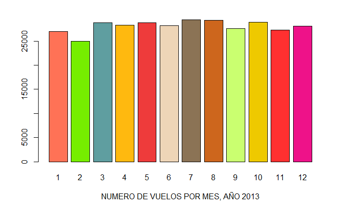

```r
colores_grafico <- c("coral1", "chartreuse2","cadetblue","darkgoldenrod1","brown2","bisque2", "burlywood4", "chocolate3", "darkolivegreen1", "gold2", "firebrick1", "deeppink2", "darkturquoise", "greenyellow", "mediumvioletred", "mediumorchid4")

barplot(table(vuelos$mes),
        xlab = "NUMERO DE VUELOS POR MES, AÑO 2013",
        col = colores_grafico,
        beside = F)
```

```r
#legend(x = "topright",
#       legend = row.names(table(vuelos$mes)),
#       fill = colores_grafico)
```

> En el grafico anterior podemos observar el numero de vuelos que han salido por mes, se puede observar, que el mes donde menos vuelos han salido es Febrero con **24951** vuelos y el mes donde mas vuelos han salido es Julio con **29425** vuelos.

**c.** Realice un gráfico de barras horizontal con alguna de las variables. Al igual que el caso anterior, debe elegir una variable que se ajuste a los requerimientos discutidos en clase para este tipo de gráficos.

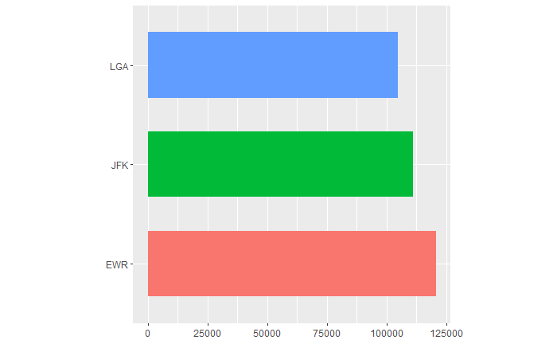

```r
bar <- ggplot(data = vuelos) +
  geom_bar(
    mapping = aes(x = origen, fill = origen),
    show.legend = F,
    width = 0.66
  ) +
  theme(aspect.ratio = 1) +
  labs(x = NULL, y = NULL)

bar + coord_flip()
```

**d.** Elija una de las variables y construya un gráfico de pastel. La variable debe tener las condiciones apropiadas.

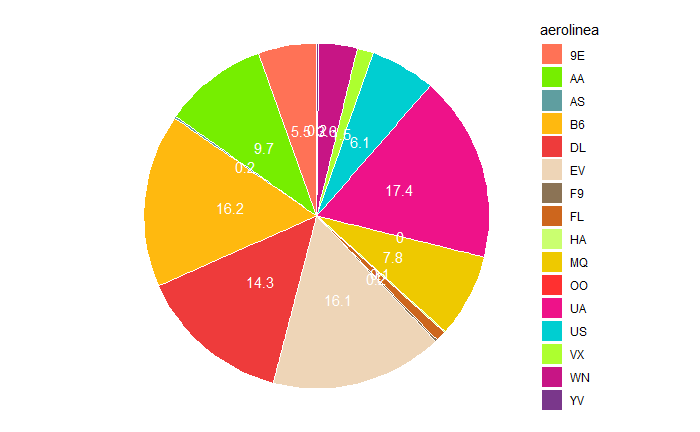

```r
aerolinea_datos <- vuelos %>%
  group_by(aerolinea) %>% # agrupar todo por clase
summarise(conteo = n())

count.data <- aerolinea_datos %>%
  arrange(desc(conteo)) %>%
  mutate(porcent = round(conteo/sum(conteo)*100,1))

count.data <- count.data %>%
  arrange(desc(aerolinea)) %>%
  mutate(lab.ypos = cumsum(porcent) - 0.5*porcent)

ggplot(count.data, aes(x = "", y = porcent, fill = aerolinea)) +
  geom_bar(width = 1, stat = "identity", color = "white") +
  coord_polar("y", start = 0)+
  geom_text(aes(y = lab.ypos, label = porcent), color = "white") +
  scale_fill_manual(values = colores_grafico) +
  theme_void()
```

> En el grafico anterior, un grafico de paste, podemos observar la distribucion de vuelos por aerolinea para el anno 2013, vemos que la aerolinea con mas vuelos gestionados es UA con 17.4% de vuelos.

Tome en cuenta que para cada gráfico debe considerar las recomendaciones estudiadas en clases, las cuáles las pueden encontrar en la presentación. Para cada uno de los gráficos, haga una breve interpretación de lo observado.